# Psychometric modeling of the Syntactic Vocabulary of the CDI

Seamus Donnelly

Note to self: these models take a long time to run, so, rather than estimating them each time I run the code, I’ve saved the models, commented out teh code for running the models, and included the code for opening the models. Be **EXTRA CAREFUL** that the saved models are the most up to date.

# 1 Preliminaries

```r
library(wordbankr) # WB data
library(tidyverse) # tidy
library(mirt) # IRT models
library(ltm) # more IRT functions
library(psych) # some psychometric stuff (tests of dimensionality)
library(Gifi)# some more psychometric stuff (tests of dimensionality)
library(knitr) # some formatting, tables, etc
library(patchwork) # combining plots.
library(GGally) # More plottinng options.
library(lordif) # differential item functioning.
```

```r
Inst <- get_instrument_data(language="English (American)", form="WS")
Admin <- get_administration_data(language="English (American)", form="WS")
N_total = nrow(Admin) # making sure things add up later
N_long = nrow(filter(Admin, longitudinal==TRUE)) # making sure things add up later
Item <- get_item_data(language="English (American)", form = "WS")
```

```r
Vocab <- Admin %>%
  full_join(.,Inst, by="data_id") %>%
  full_join(., Item, by="num_item_id") %>%
  filter(longitudinal==FALSE) %>% # remove longitudinal data set
  filter(type == "word"
         ) %>%
  mutate(
    out = ifelse(value=="produces", yes=1, no =0)
    )

N_vocab = nrow(filter(Item, type == "word"))

nrow(Vocab) == (N_total - N_long)*N_vocab
```

```
## [1] TRUE
```

```r
Vocab %>%
  filter(is.na(out)) %>%
  group_by(definition) %>%
  count()
```

| definition | n |
| --- | --- |
| a | 21 |
| a lot | 16 |
| about | 25 |
| above | 24 |
| after | 13 |
| airplane | 6 |
| all | 16 |
| all gone | 7 |
| alligator | 14 |
| am | 21 |

[output cut: 670 more lines]

Number of missing items differs by word. How can this be??

Check distribution of missing values by source.

```r
Vocab %>%
  filter(is.na(out)) %>%
  group_by(source_name) %>%
  count()
```

| source_name | n |
| --- | --- |
| Byers | 9122 |
| Marchman (Outreach1) | 1 |

These all seem to come from a single study (- 1).

```r
Vocab %>%
  group_by(source_name) %>%
  count()
```

| source_name | n |
| --- | --- |
| Byers | 18360 |
| Marchman (Dallas) | 505920 |
| Marchman (Norming) | 960840 |
| Marchman (Outreach1) | 47600 |
| Marchman (Wisconsin) | 381480 |
| Smith (electronic) | 428400 |
| Smith (paper) | 522920 |

```r
Vocab %>%
 filter(is.na(out)) %>%
 filter(source_name=="Marchman (Outreach1)")
```

| data_id | age | comprehension | production | language.x | form.x | birth_order | ethnicity | sex | zygosity | norming | mom_ed | longitudinal | source_name | license | value | num_item_id | item_id | definition | language.y | form.y | type | category | lexical_category | lexical_class | uni_lemma | complexity_category | out |
| --- | --- | --- | --- | --- | --- | --- | --- | --- | --- | --- | --- | --- | --- | --- | --- | --- | --- | --- | --- | --- | --- | --- | --- | --- | --- | --- | --- |
| 135056 | 23 | 604 | 604 | English (American) | WS | Second | NA | Female | NA | FALSE | Some College | FALSE | Marchman (Outreach1) | CC-BY | NA | 33 | item_33 | goose | English (American) | WS | word | animals | nouns | nouns | goose |  | NA |

No idea why this word is missing. I’m removing all these participants from the IRT models.

```r
N_missing <- Vocab %>%
  filter(is.na(out)) %>%
  group_by(data_id) %>%
  slice(1) %>%
  ungroup(data_id) %>%
  count()
```

```r
Vocab %>%
  filter(!is.na(out)) %>%
  group_by(definition) %>%
  summarise(
    mean=mean(out),
    sd=sd(out),
    category = first(lexical_category)
  ) %>%
  arrange(category) %>%
  kable(caption="Means and SDs for Each Item (Arranged by Item)")
```

Means and SDs for Each Item (Arranged by Item)

| definition | mean | sd | category |
| --- | --- | --- | --- |
| a | 0.2880992 | 0.4529315 | function_words |
| a lot | 0.1881848 | 0.3909063 | function_words |
| about | 0.0732872 | 0.2606384 | function_words |
| above | 0.0909308 | 0.2875450 | function_words |
| all | 0.3041925 | 0.4601194 | function_words |
| am | 0.1834009 | 0.3870410 | function_words |
| an | 0.0663643 | 0.2489475 | function_words |
| and | 0.2560191 | 0.4364845 | function_words |
| another | 0.2240229 | 0.4169869 | function_words |
| any | 0.1541766 | 0.3611611 | function_words |
| are | 0.1529103 | 0.3599440 | function_words |
| around | 0.1664679 | 0.3725446 | function_words |
| at | 0.2131617 | 0.4095898 | function_words |
| away | 0.2717961 | 0.4449383 | function_words |
| back | 0.3266667 | 0.4690500 | function_words |
| be | 0.1469466 | 0.3540949 | function_words |
| because | 0.1382191 | 0.3451711 | function_words |
| behind | 0.1869783 | 0.3899406 | function_words |
| beside | 0.0822996 | 0.2748534 | function_words |
| but | 0.0945333 | 0.2926042 | function_words |
| by | 0.1967096 | 0.3975583 | function_words |
| can (auxiliary) | 0.2479182 | 0.4318554 | function_words |
| could | 0.0761518 | 0.2652725 | function_words |
| did/did ya | 0.2269368 | 0.4189013 | function_words |
| do | 0.4020937 | 0.4903790 | function_words |
| does | 0.1195419 | 0.3244638 | function_words |
| don’t | 0.3340481 | 0.4717128 | function_words |
| down | 0.6519981 | 0.4763933 | function_words |
| each | 0.0591885 | 0.2360054 | function_words |
| every | 0.0983294 | 0.2977950 | function_words |

[output cut: 650 more lines]

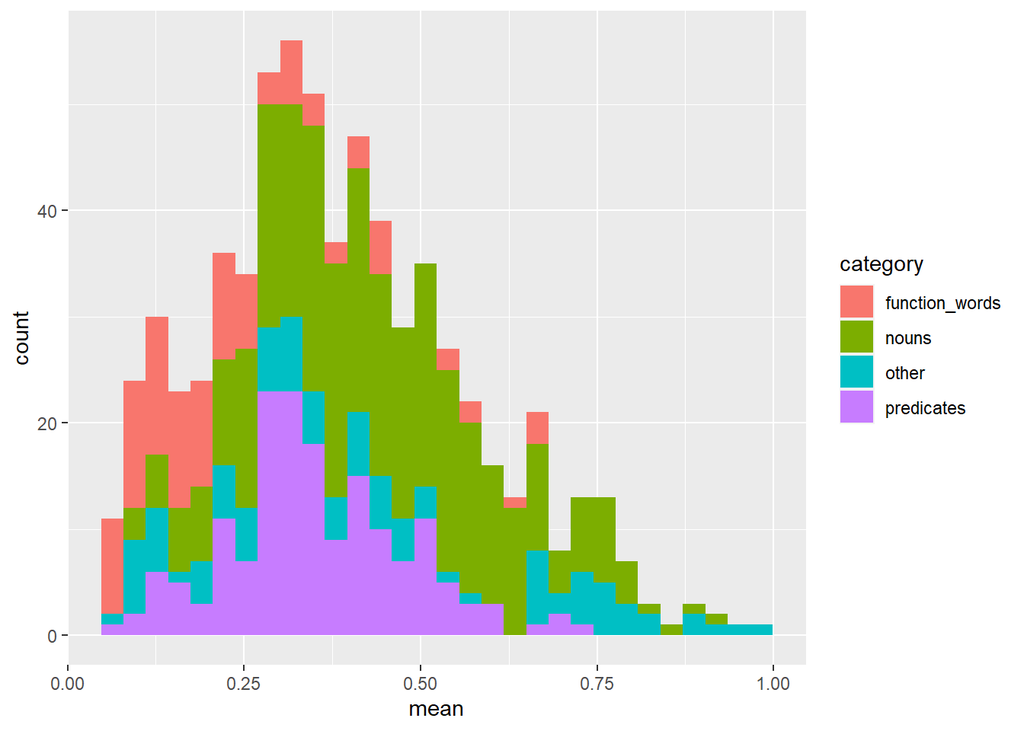

```r
Vocab %>%
  filter(!is.na(out)) %>%
  group_by(definition) %>%
  summarise(
    mean=mean(out),
    sd=sd(out),
    category = first(lexical_category)
  ) %>%
  ggplot(aes(x=mean, fill=category)) + geom_histogram()
```

Stick to just nouns and predicates as these are relatively clearly not grammatical items.

```r
Vocab_short_with_ids <- Vocab %>%
  filter(lexical_category == "nouns" | lexical_category == "predicates") %>%
  dplyr::select(data_id, value, out, definition) %>%
  pivot_wider(id_cols=data_id, names_from = "definition", values_from="out") %>%
  drop_na() # drop participants with missing data


Vocab_short <- Vocab_short_with_ids %>%
  dplyr::select(-"data_id") # dataset for IRT can't have IDs

nrow(Vocab_short_with_ids) == N_total - N_long - N_missing # Looks good
```

```
##         n
## [1,] TRUE
```

# 2 Dimensionality assessment

I’m not going to bother with the correlation plot because I think it will be too difficult to visualize.

```r
Complex_poly <- tetrachoric(Vocab_short)
```

```
## For i = 131 j = 58  A cell entry of 0 was replaced with correct =  0.5.  Check your data!
```

```
## For i = 160 j = 58  A cell entry of 0 was replaced with correct =  0.5.  Check your data!
```

```
## For i = 225 j = 58  A cell entry of 0 was replaced with correct =  0.5.  Check your data!
```

```
## For i = 387 j = 58  A cell entry of 0 was replaced with correct =  0.5.  Check your data!
```

```
## For i = 448 j = 445  A cell entry of 0 was replaced with correct =  0.5.  Check your data!
```

```r
rho <- Complex_poly$rho
```

These will not run.

```r
#pc <- princals(rho)

#plot(pc)
```

```r
fa.parallel(rho, fa="fa", fm="minres", cor="poly", n.obs = 4186)
```

```
## The determinant of the smoothed correlation was zero.
## This means the objective function is not defined.
## Chi square is based upon observed residuals.
```

```
## The determinant of the smoothed correlation was zero.
## This means the objective function is not defined for the null model either.
## The Chi square is thus based upon observed correlations.
```

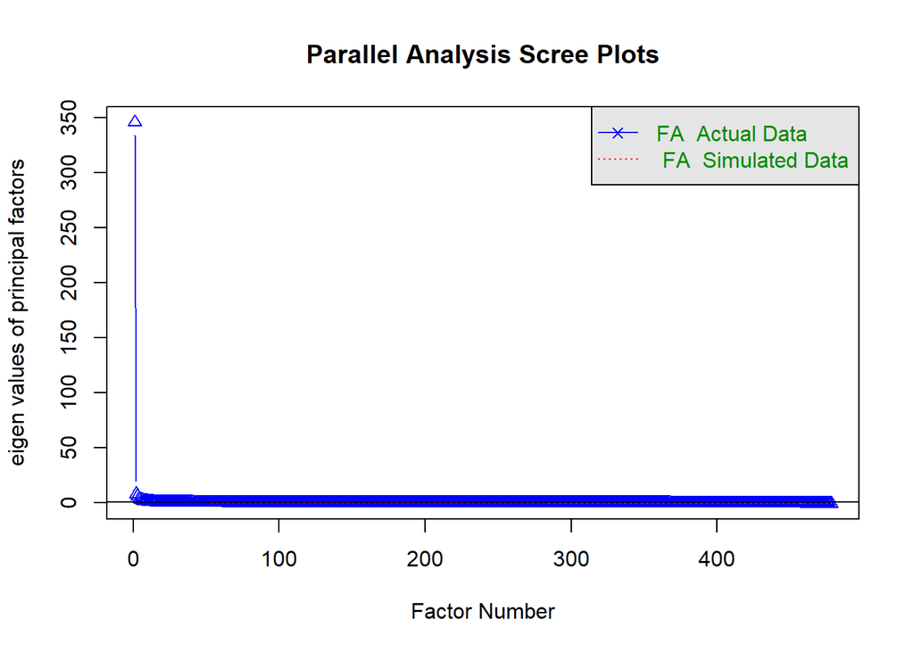

```
## Parallel analysis suggests that the number of factors =  22  and the number of components =  NA
```

# 3 One dimension

## 3.1 2PL Model

```r
#m1 <- mirt(Vocab_short, 1, itemtype="2PL")
#saveRDS(m1, "vocab_output/m1.rds")
m1 <-  readRDS("vocab_output/m1.rds")
```

Looking at item misfit statistics

```r
#itf <- itemfit(m1)
#saveRDS(itf, "vocab_output/itf.rds")
itf <- readRDS("vocab_output/itf.rds")
```

```r
misfit <- itf  %>% # Get labels of mis-fitting items.
  filter(p.S_X2 <= .01) %>%
  dplyr::select(item) %>%
  as.vector()

items_good <- dplyr::select(Vocab_short, -all_of(misfit$item)) # Well fitting items
items_bad <- dplyr::select(Vocab_short, all_of(misfit$item)) # Poorly fitting items

mod_fit <- mirt(items_good, 1, "2PL", verbose=FALSE) # Calculate factor scores using only the well fitting items.
Theta <- fscores(mod_fit)
```

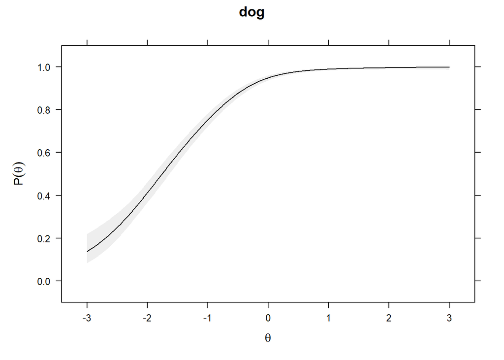

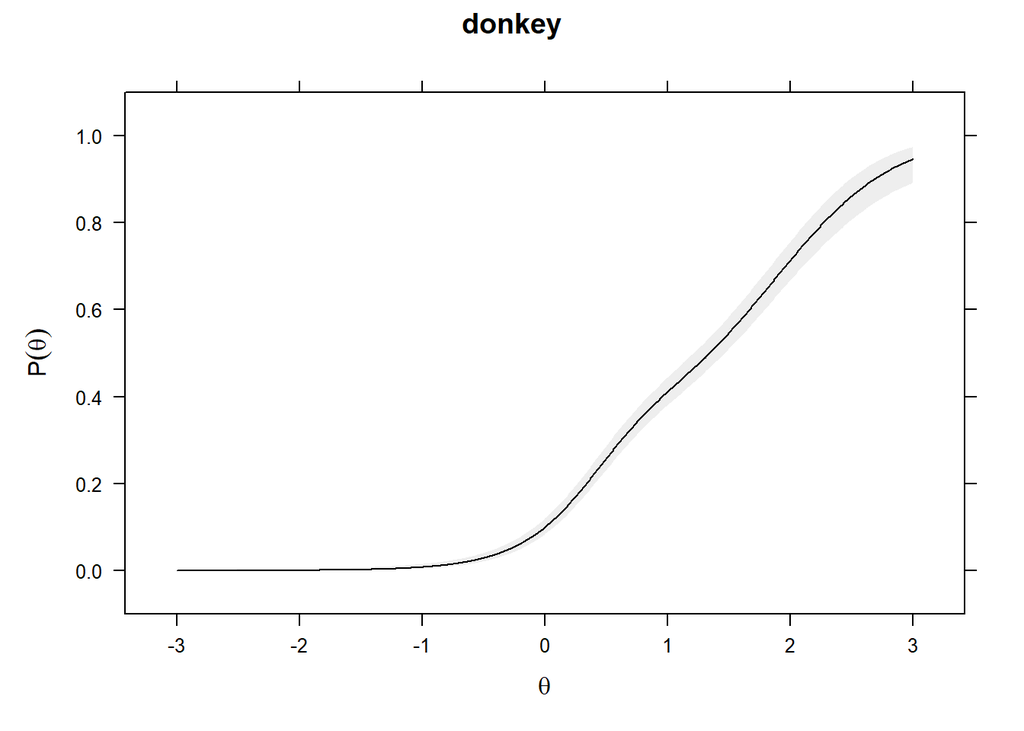

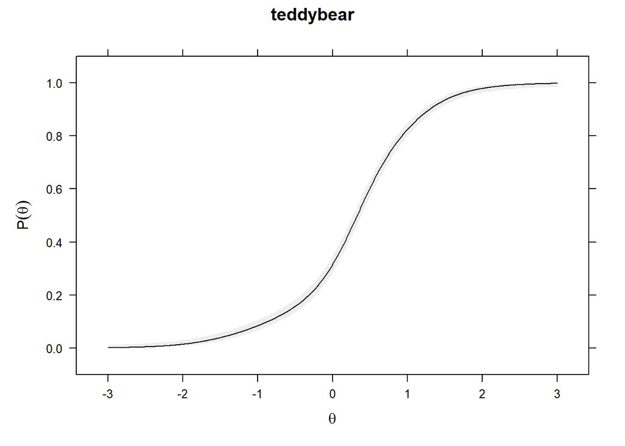

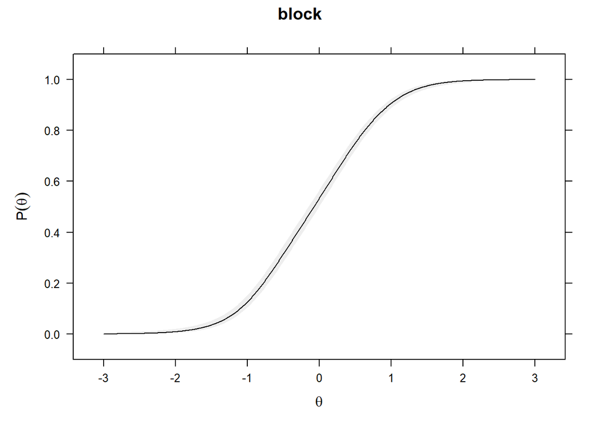

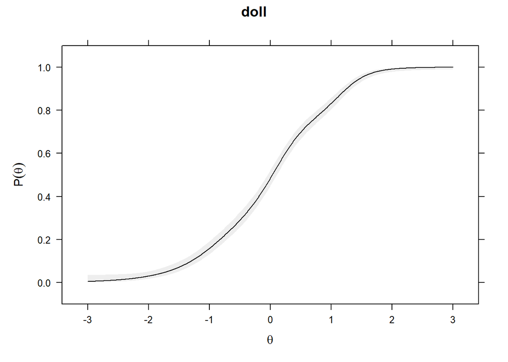

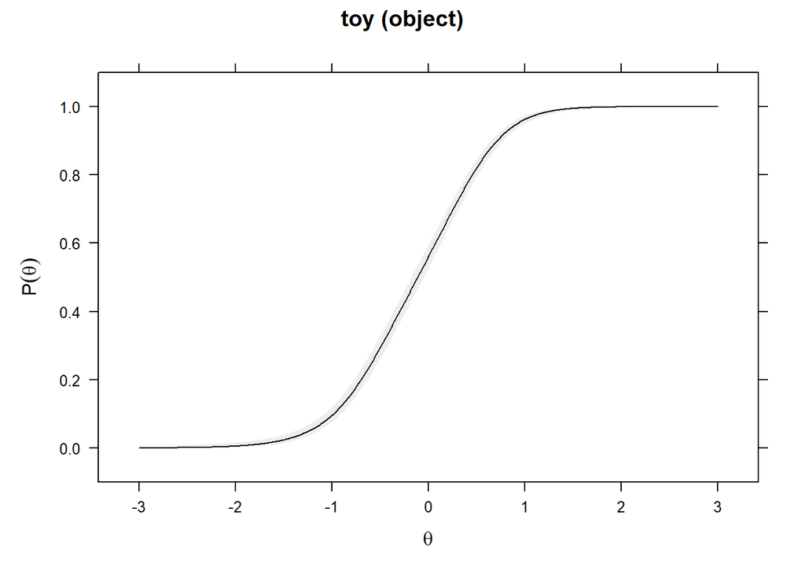

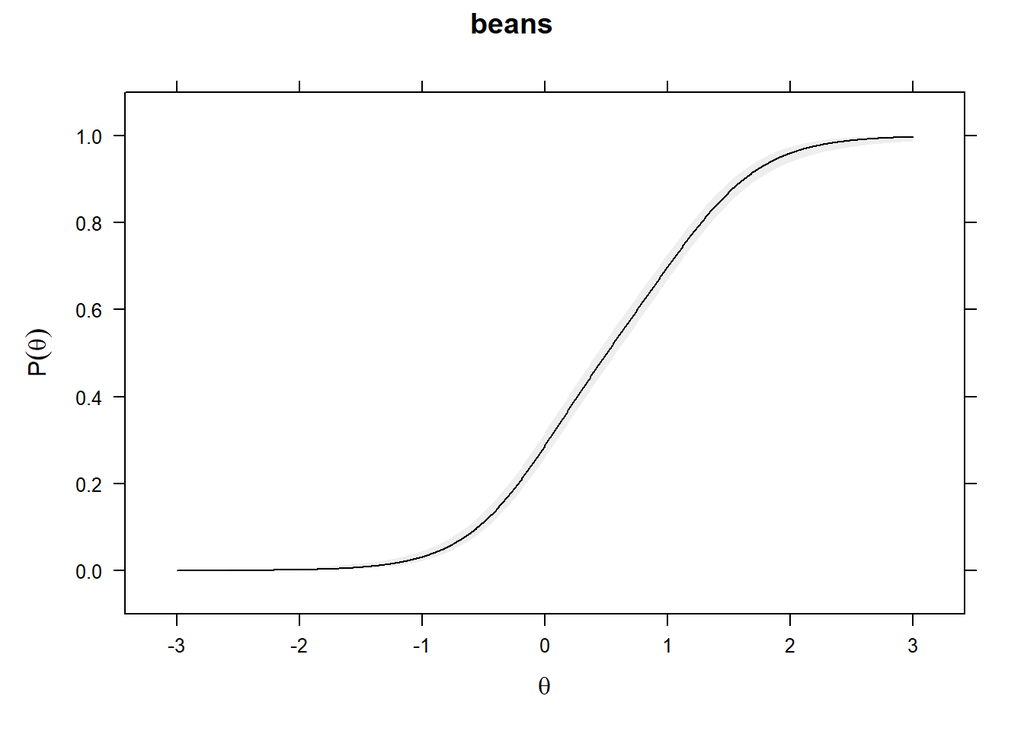

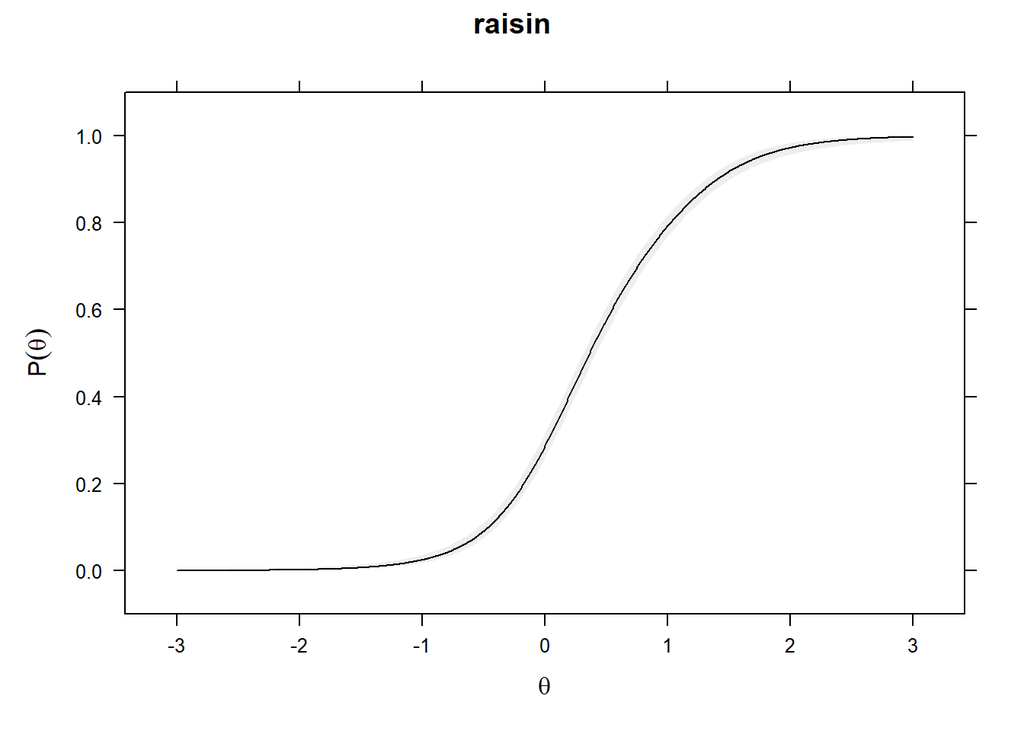

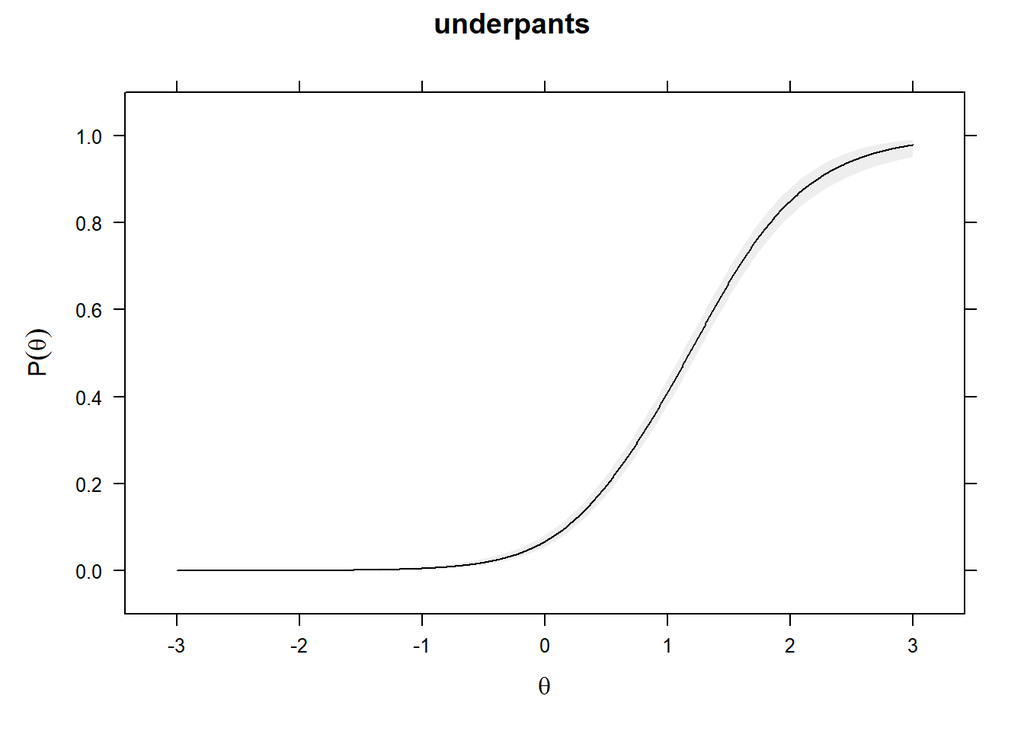

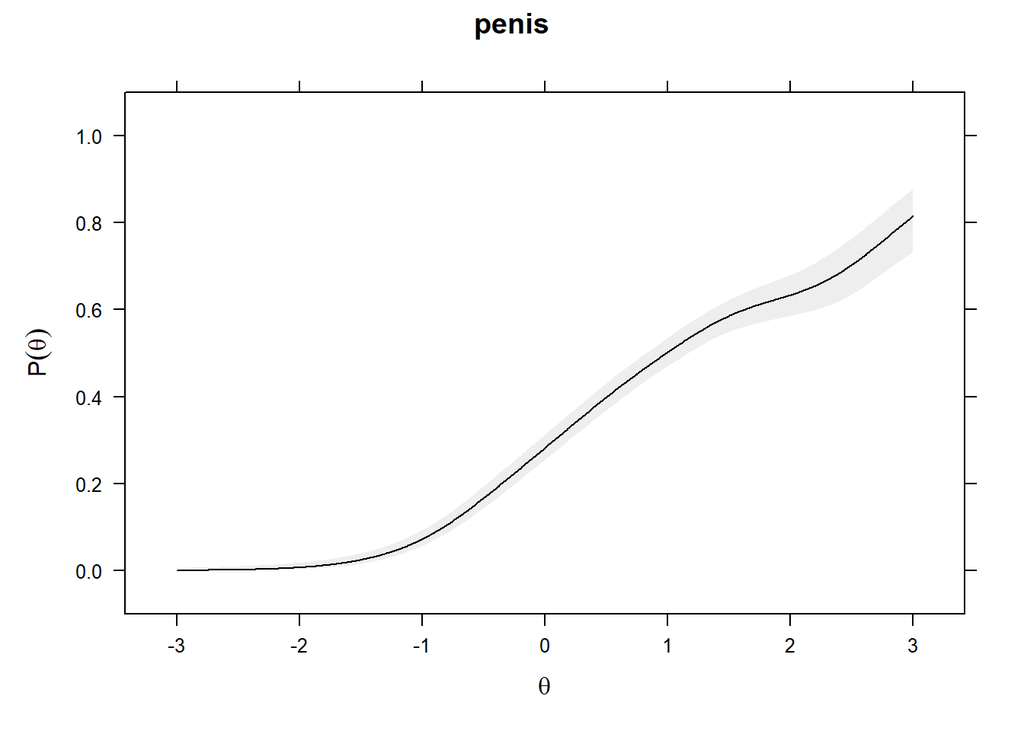

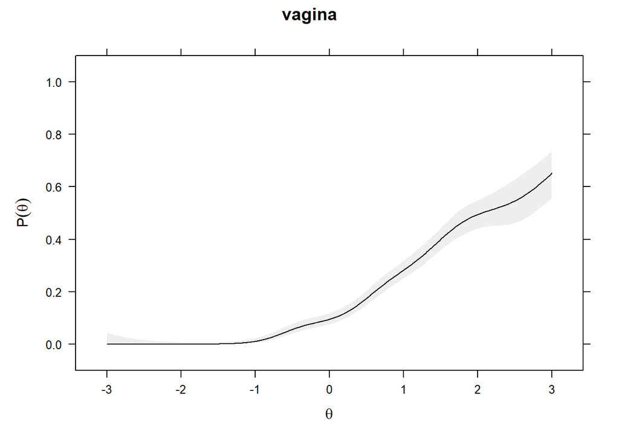

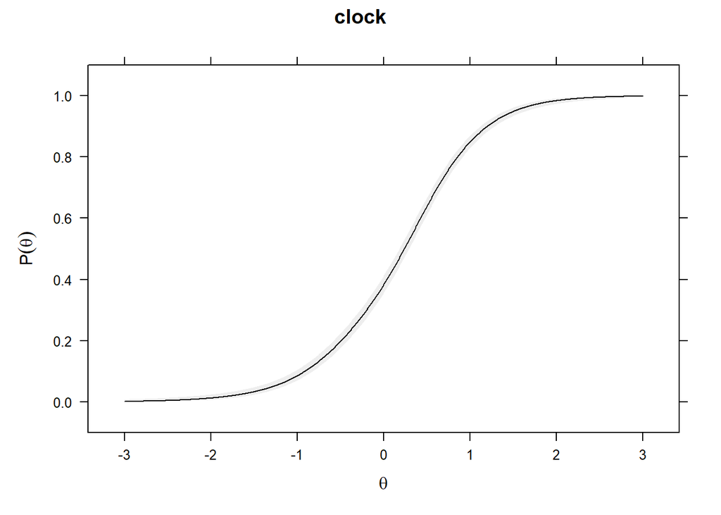

[6 more figures not shown]

```r
plot(itemGAM(items_bad$dog, Theta)) %>% update(main = "dog")
plot(itemGAM(items_bad$donkey,Theta)) %>% update(main = "donkey")
plot(itemGAM(items_bad$teddybear,Theta)) %>% update(main = "teddybear")
plot(itemGAM(items_bad$block,Theta)) %>% update(main = "block")
plot(itemGAM(items_bad$doll,Theta)) %>% update(main = "doll")
plot(itemGAM(items_bad$`toy (object)`,Theta)) %>% update(main = "toy (object)")
plot(itemGAM(items_bad$beans,Theta)) %>% update(main = "beans")
plot(itemGAM(items_bad$raisin,Theta)) %>% update(main = "raisin")
plot(itemGAM(items_bad$underpants,Theta)) %>% update(main = "underpants")
plot(itemGAM(items_bad$`penis*`,Theta)) %>% update(main = "penis")
plot(itemGAM(items_bad$`vagina*`,Theta)) %>% update(main = "vagina")
plot(itemGAM(items_bad$clock,Theta)) %>% update(main = "clock")
plot(itemGAM(items_bad$dish,Theta)) %>% update(main = "dish")
plot(itemGAM(items_bad$keys,Theta)) %>% update(main = "keys")
plot(itemGAM(items_bad$plate,Theta)) %>% update(main = "plate")
plot(itemGAM(items_bad$trash,Theta)) %>% update(main = "trash")
plot(itemGAM(items_bad$bathtub,Theta)) %>% update(main = "bathtub")
plot(itemGAM(items_bad$TV,Theta)) %>% update(main = "TV")
```

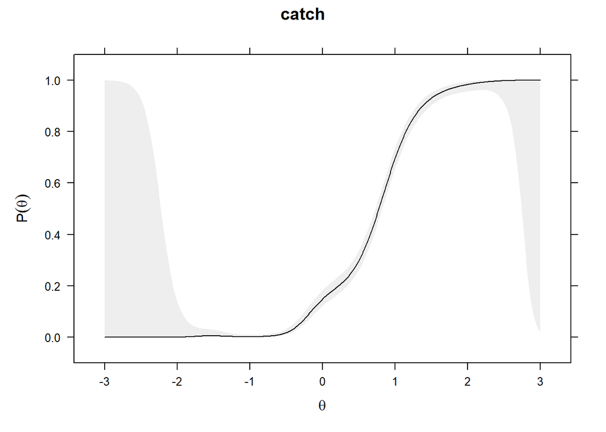

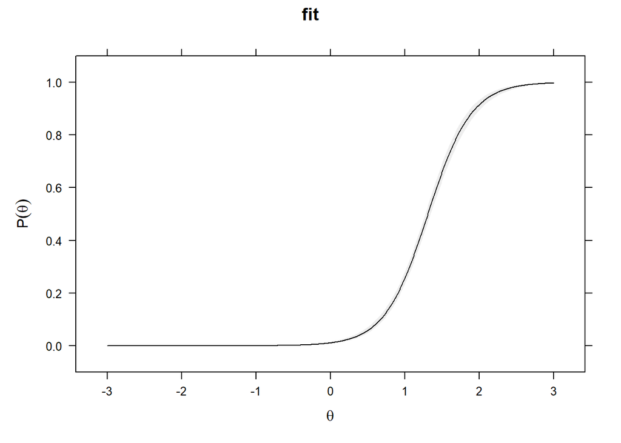

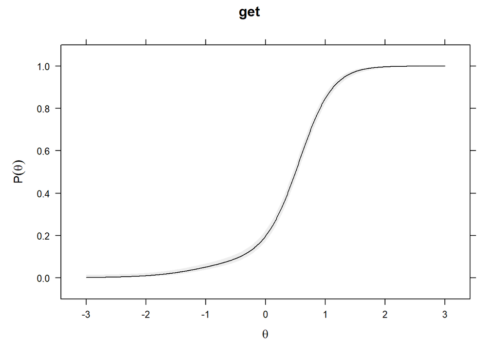

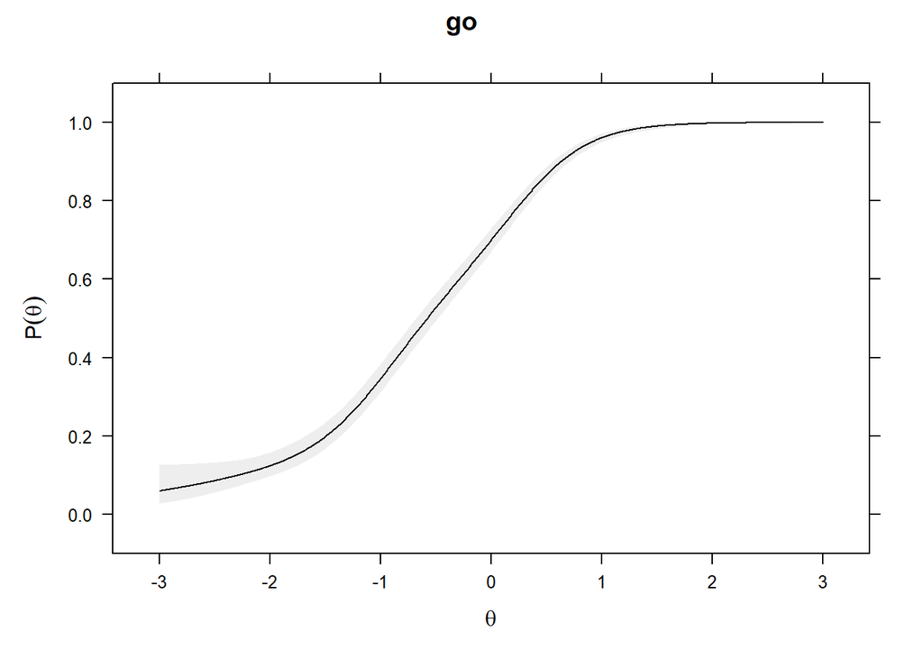

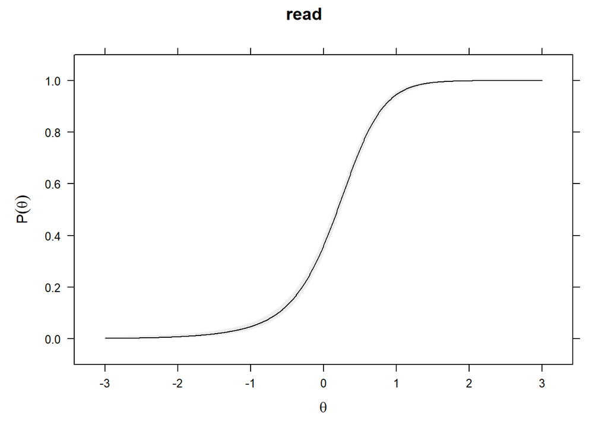

```r
plot(itemGAM(items_bad$catch, Theta)) %>% update(main = "catch")
plot(itemGAM(items_bad$fit,Theta))  %>% update(main = "fit")
plot(itemGAM(items_bad$get,Theta)) %>% update(main = "get")
plot(itemGAM(items_bad$go,Theta)) %>% update(main = "go")
plot(itemGAM(items_bad$read,Theta)) %>% update(main = "read")
```

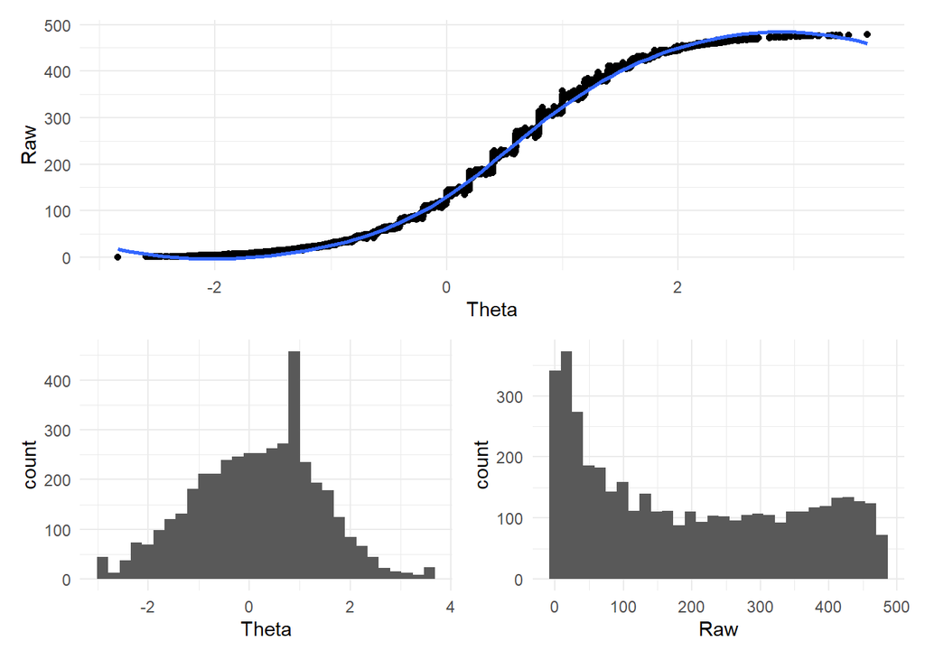

```r
true_raw <- Vocab_short %>%
  mutate(
    Raw = rowSums(.[,1:478]),
    Theta = fscores(m1)
  ) %>%
  ggplot(aes(x=Theta, y=Raw)) + geom_point() + stat_smooth(method="loess") + theme_minimal()

raw_score <- Vocab_short %>%
  mutate(
    Raw = rowSums(.[,1:478])
    ) %>%
   ggplot(aes(x=Raw)) + geom_histogram() + theme_minimal()

true_score <- Vocab_short %>%
  mutate(
    Theta = fscores(m1)
    ) %>%
   ggplot(aes(x=Theta)) + geom_histogram() + theme_minimal()

library(patchwork)

true_raw/(true_score + raw_score)
```

```r
coefs_2pl <- coef(m1, as.data.frame = TRUE) %>%
 t() %>%
  as_tibble() %>%
  dplyr::select(-c(1913:1914)) %>%
  pivot_longer(everything()) %>%
  tidyr::separate(, col=name, into=c("item", "parameter"), sep="([.])") %>%
  filter(parameter == "a1" | parameter == "d" ) %>%
  pivot_wider(id_cols=item, names_from=parameter, values_from=value)
```

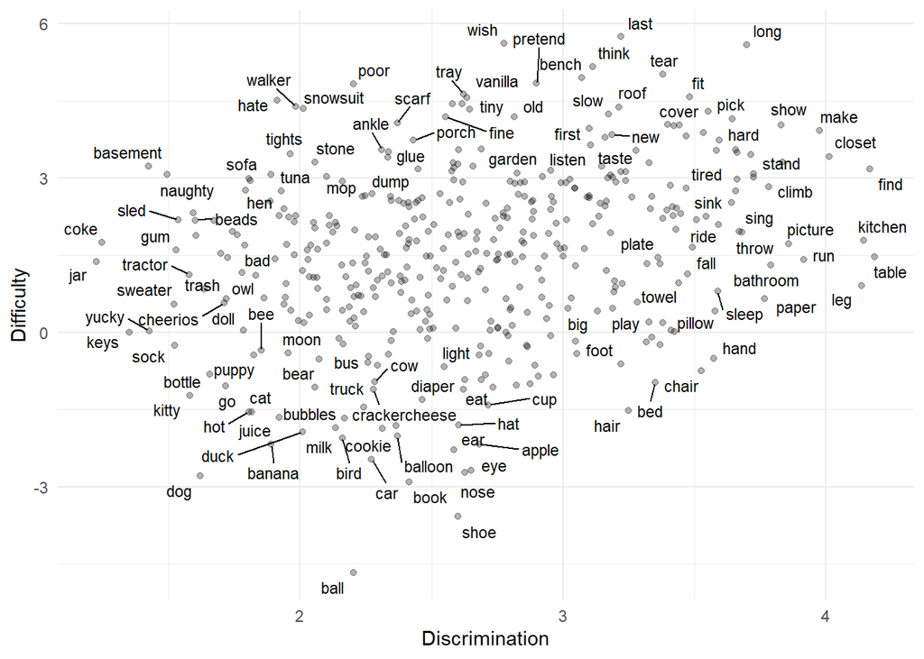

```r
ggplot(coefs_2pl,
       aes(x = a1, y = -d)) + # Note in the book they use -d here, I think MIRT outputs a1 and an easiness rather than a difficulty.
  geom_point(alpha = .3) +
  ggrepel::geom_text_repel(data = coefs_2pl,
                  aes(label = item), size = 3) +
  xlab("Discrimination") +
  ylab("Difficulty") + theme_minimal()
```

```r
#ggplot(coefs_2pl, aes(x=a1, fill=lexical_category)) + geom_histogram() + theme_minimal()
#ggplot(coefs_2pl, aes(x=d, fill=lexical_category)) + geom_histogram() + theme_minimal()
```

## 3.2 Try changing to a non-parametric link function

These discrimination parameters look good, but I’m not crazy about the item response functions, so I will try a spline model .

```r
#m2 <- mirt(Vocab_short, 1, "spline", technical=list(NCYCLES = 1000)) # I can increase iterations, but it just jumps around the same few values.
#saveRDS(m2, "vocab_output/m2.rds")
m2 <-  readRDS("vocab_output/m2.rds")
```

Plot latent variables of spline model against 2PL model.

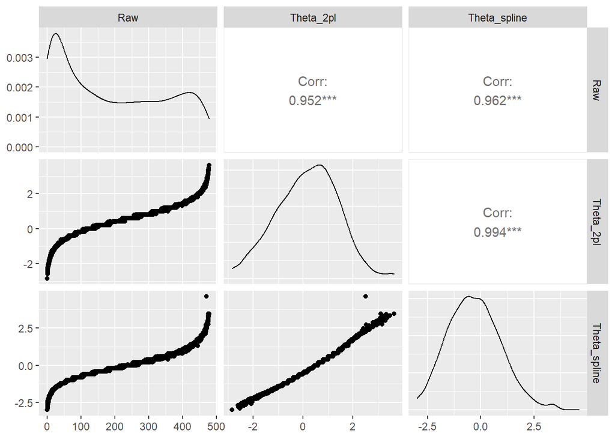

```r
Vocab_short %>%
  mutate(
    Raw = rowSums(.[,1:478]),
    Theta_2pl = fscores(m1)[,1],
    Theta_spline = fscores(m2)[,1]
  ) %>%
  dplyr::select("Raw", "Theta_2pl", "Theta_spline") %>%
  ggpairs()
```

## 3.3 Try other latent variable

```r
#m3 <- mirt(Vocab_short, 1, dentype="EH",  technical=list(NCYCLES = 2000))
#saveRDS(m3, "vocab_output/m3.rds")
m3 <- readRDS("vocab_output/m3.rds")
```

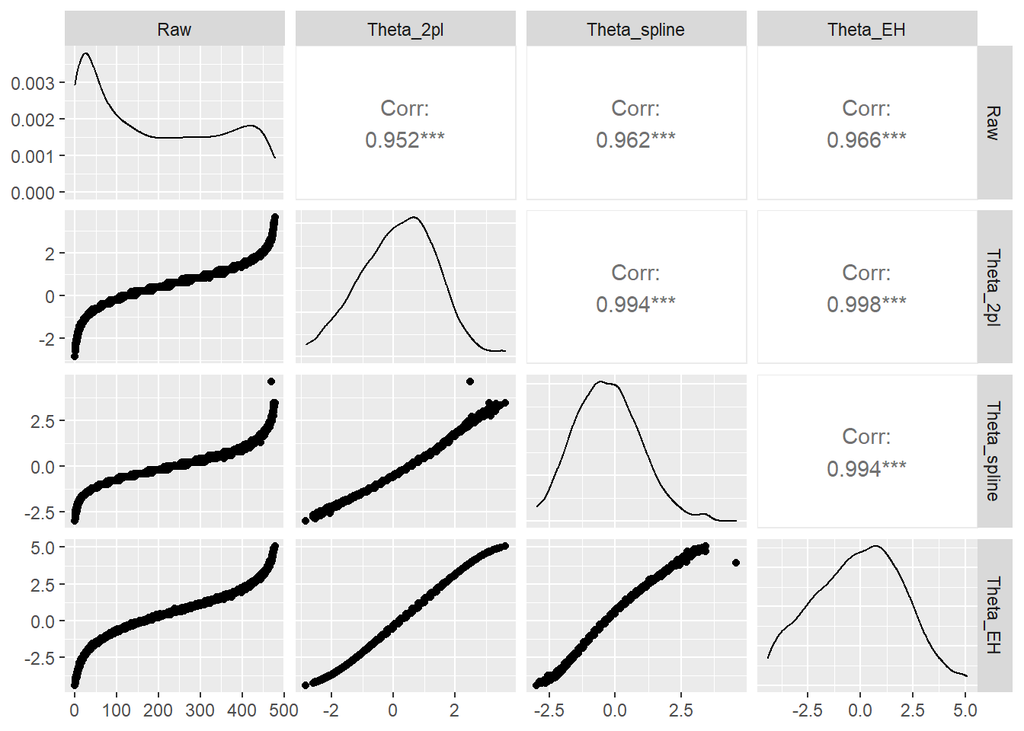

```r
Vocab_short %>%
  mutate(
    Raw = rowSums(.[,1:478]),
    Theta_2pl = fscores(m1)[,1],
    Theta_spline = fscores(m2)[,1],
    Theta_EH =  fscores(m3)[,1]
  ) %>%
  dplyr::select("Raw", "Theta_2pl", "Theta_spline", "Theta_EH") %>%
  ggpairs()
```

Compare the shape of distribution of latent variables.

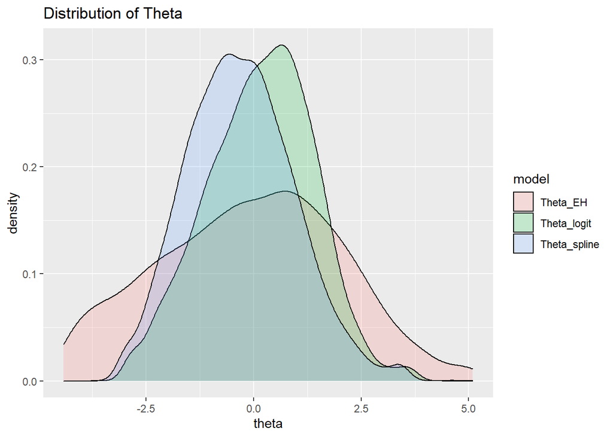

```r
(dens_plot <- Vocab_short %>%
  mutate(
    Theta_logit = fscores(m1)[,1], # Used MAP here, but EAP gives same results.
    Theta_spline = fscores(m2)[,1],
    Theta_EH = fscores(m3)[,1]
  ) %>%
  dplyr::select("Theta_logit", "Theta_spline", "Theta_EH") %>%
  pivot_longer(everything(), names_to="model", values_to="theta") %>%
  ggplot(aes(x=theta, fill=model)) + geom_density(alpha = .2) +
  ggtitle("Distribution of Theta"))
```

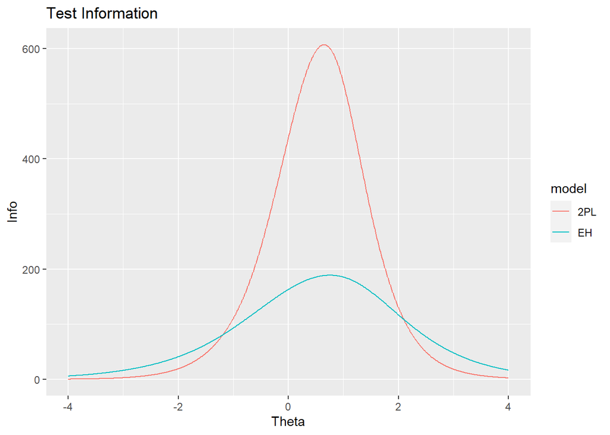

```r
Theta <- matrix(seq(-4,4,.01))
m1_inf <- testinfo(m1, Theta)
#mspline_inf <- testinfo(m2, Theta)
mEH_inf <- testinfo(m3, Theta)


(info_plot <- tibble(Theta, m1_inf, mEH_inf) %>%
   pivot_longer(c("m1_inf", "mEH_inf"), names_to = "LV", values_to = "Info") %>%
  mutate(
    model = ifelse(LV == "m1_inf", yes="2PL", no ="EH")
  ) %>%
  ggplot(aes(x=Theta, y=Info, group=model, color=model)) + geom_line() +
  ggtitle("Test Information"))
```

```r
coefs_2pl <- coef(m3, as.data.frame = TRUE) %>%
 t() %>%
  as_tibble() %>%
  dplyr::select(-c(1913:1914)) %>%
  pivot_longer(everything()) %>%
  tidyr::separate(, col=name, into=c("item", "parameter"), sep="([.])") %>%
  filter(parameter == "a1" | parameter == "d" ) %>%
  pivot_wider(id_cols=item, names_from=parameter, values_from=value)
```

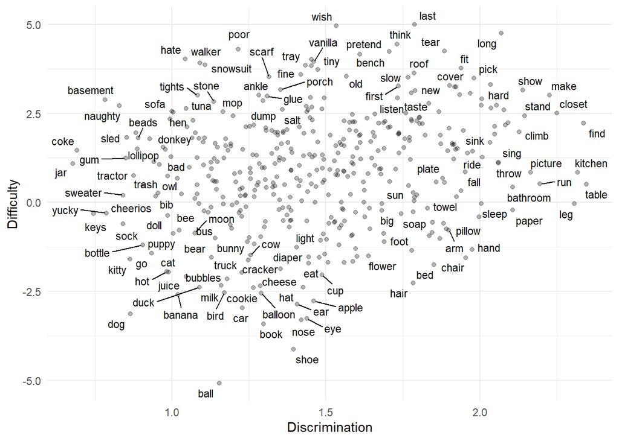

```r
ggplot(coefs_2pl,
       aes(x = a1, y = -d)) + # Note in the book they use -d here, I think MIRT outputs a1 and -d
  geom_point(alpha = .3) +
  ggrepel::geom_text_repel(data = coefs_2pl,
                  aes(label = item), size = 3) +
  xlab("Discrimination") +
  ylab("Difficulty") + theme_minimal()
```

# 4 Add a dimension

Compare this to a model with 2 dimensions.

```r
#m4<- mirt(Vocab_short, 2, itemtype="2PL", technical=list(NCYCLES = 4000))
#saveRDS(m4, "vocab_output/m4.rds")
m4 <-  readRDS("vocab_output/m4.rds")
```

```r
summary(m4, "oblimin", suppress=.20)
```

```
##
## Rotation:  oblimin
##
## Rotated factor loadings:
##
##                          F1     F2    h2
## alligator            -0.858     NA 0.784
## animal               -0.847     NA 0.737
## ant                  -0.787     NA 0.633
## bear                 -0.781 -0.213 0.666
## bee                  -0.754 -0.204 0.620
## bird                 -0.794     NA 0.676
## bug                  -0.806     NA 0.658
## bunny                -0.812     NA 0.692
## butterfly            -0.845     NA 0.764
## cat                  -0.748     NA 0.578
## chicken (animal)     -0.852     NA 0.757
## cow                  -0.810 -0.208 0.711
## deer                 -0.736 -0.236 0.608
## dog                  -0.710     NA 0.516
## donkey               -0.735 -0.261 0.621
## duck                 -0.770 -0.252 0.669
## elephant             -0.874     NA 0.813
## fish (animal)        -0.832     NA 0.727
## frog                 -0.858 -0.219 0.796
## giraffe              -0.807 -0.266 0.735
## goose                -0.752 -0.237 0.633
## hen                  -0.762 -0.212 0.636
## horse                -0.871     NA 0.792
## kitty                -0.709     NA 0.508
## lamb                 -0.810 -0.201 0.707
## lion                 -0.863 -0.216 0.803
## monkey               -0.865     NA 0.798
## moose                -0.718 -0.285 0.610
## mouse                -0.852     NA 0.770
## owl                  -0.733 -0.297 0.640
## penguin              -0.799 -0.206 0.690
## pig                  -0.868     NA 0.793
## pony                 -0.778     NA 0.637
## puppy                -0.757     NA 0.578
```

[output cut: 437 more lines]

```
## tiny                 -0.860     NA 0.741
## tired                -0.914     NA 0.848
## wet                  -0.884     NA 0.783
## white                -0.842     NA 0.715
## windy                -0.875     NA 0.766
## yellow               -0.776     NA 0.635
## yucky                -0.582 -0.208 0.389
##
## Rotated SS loadings:  343.784 7.129
##
## Factor correlations:
##
##       F1    F2
## F1 1.000 0.032
## F2 0.032 1.000
```

```r
anova(m4, m1)
```

```
##
## Model 1: mirt(data = Vocab_short, model = 1, itemtype = "2PL")
## Model 2: mirt(data = Vocab_short, model = 2, itemtype = "2PL", technical = list(NCYCLES = 4000))
```

| AIC | AICc | SABIC | HQ | BIC | logLik | X2 | df | p |
| --- | --- | --- | --- | --- | --- | --- | --- | --- |
| 1275351 | 1275918 | 1278374 | 1277494 | 1281412 | -636719.6 | NaN | NaN | NaN |
| 1248351 | 1249844 | 1252882 | 1251563 | 1257435 | -622742.3 | 27954.5 | 477 | 0 |

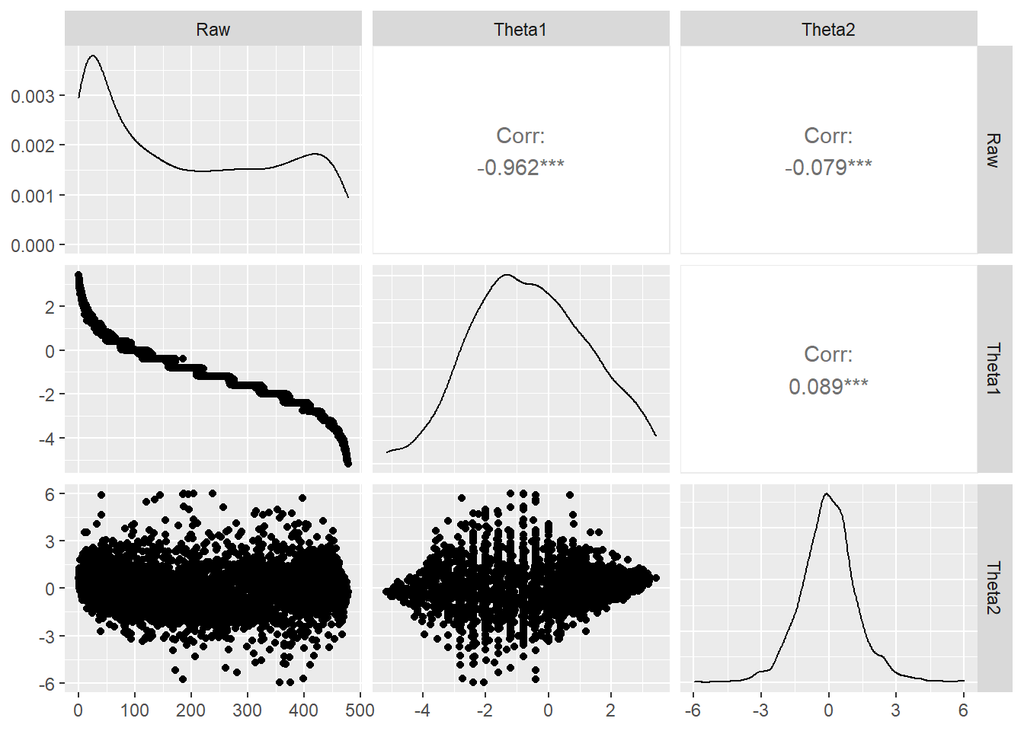

```r
Vocab_short %>%
  mutate(
    Raw = rowSums(.[,1:478]),
    Theta1 = fscores(m4)[,1],
    Theta2 = fscores(m4)[,2]
  ) %>%
  dplyr::select(Raw, Theta1, Theta2) %>%
  ggpairs()
```

Second factor doesn’t look like it’s doing much work.

```r
model.1 <- mirt.model('
                      F1 = 1 - 312
                      F2 = 313 - 478
                      COV=F1*F2')

#m5 <- mirt(Vocab_short, model.1, "2PL")


#summary(m5)

#saveRDS(m5, "vocab_output/m5.rds")
m5 <-  readRDS("vocab_output/m5.rds")
```

```r
anova(m5, m1)
```

```
##
## Model 1: mirt(data = Vocab_short, model = 1, itemtype = "2PL")
## Model 2: mirt(data = Vocab_short, model = model.1, itemtype = "2PL")
```

| AIC | AICc | SABIC | HQ | BIC | logLik | X2 | df | p |
| --- | --- | --- | --- | --- | --- | --- | --- | --- |
| 1275351 | 1275918 | 1278374 | 1277494 | 1281412 | -636719.6 | NaN | NaN | NaN |
| 1256761 | 1257329 | 1259787 | 1258906 | 1262828 | -627423.4 | 18592.4 | 1 | 0 |

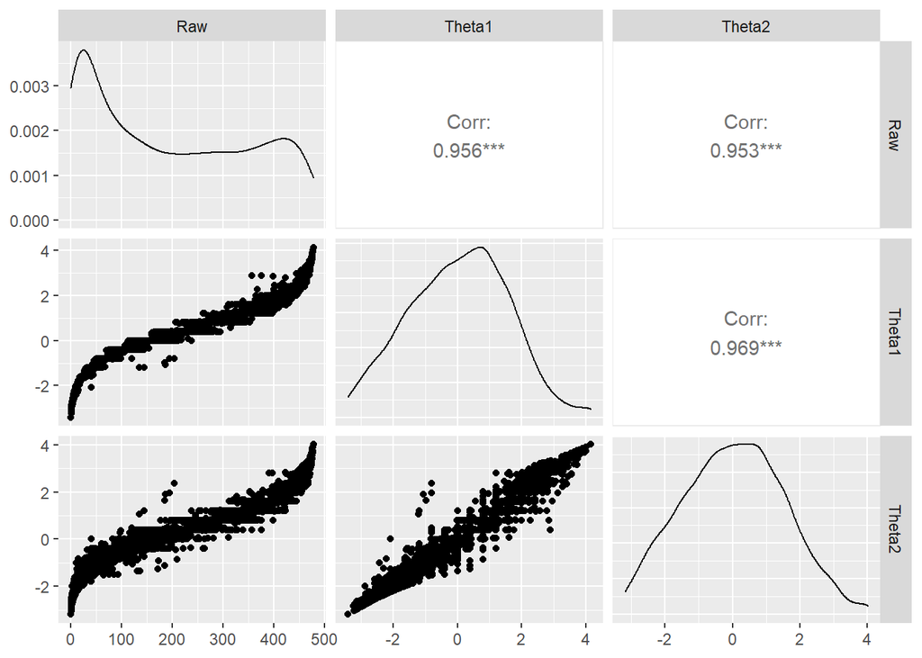

```r
Vocab_short %>%
  mutate(
    Raw = rowSums(.[,1:478]),
    Theta1 = fscores(m5)[,1],
    Theta2 = fscores(m5)[,2]
  ) %>%
  dplyr::select(Raw, Theta1, Theta2) %>%
  ggpairs()
```

```r
Vocab_with_predictors <- Admin %>%
  dplyr::select(data_id, age, ethnicity, sex, mom_ed) %>%
  mutate(
    female = ifelse(sex=="Female", yes=1, no=0),
   age_y = ifelse(age < 25, yes=1, no=0),
   college_grad = ifelse(mom_ed %in% c("College", "Some Graduate",  "Some Graduate"), yes=1, no=0)
   ) %>%
  right_join(., Vocab_short_with_ids, by="data_id")
```

```r
Vocab_with_predictors %>%
  summarise(
    age_missing = sum(is.na(age)),
    ethnicity_missing = sum(is.na(ethnicity)), # Some ethnicity variables missing.
    sex_missing = sum(is.na(sex)),
    college_grad = sum(is.na(college_grad))
  )
```

| age_missing | ethnicity_missing | sex_missing | college_grad |
| --- | --- | --- | --- |
| 0 | 1471 | 1399 | 0 |

```r
table(Vocab_with_predictors$age)
```

```
##
##  16  17  18  19  20  21  22  23  24  25  26  27  28  29  30
## 305 271 442 327 273 203 200 261 569 324 180 194 145 197 295
```

```r
table(Vocab_with_predictors$ethnicity)
```

```
##
##    Asian    Black    Other    White Hispanic
##       67      222       93     2202      131
```

```r
table(Vocab_with_predictors$sex)
```

```
##
## Female   Male  Other
##   1374   1413      0
```

```r
table(Vocab_with_predictors$college_grad)
```

```
##
##    0    1
## 3154 1032
```

```r
#Vocab_short2 <- data.frame(Vocab_short)

#dif <- lordif(Vocab_short2,
#              Vocab_with_predictors$female,
#              criterion="Chisqr",
#              alpha = .01)

#saveRDS(dif, "vocab_output/dif.rds")
dif  <- readRDS("vocab_output/dif.rds")
```

```r
dif
```

```
## Call:
## lordif(resp.data = Vocab_short2, group = Vocab_with_predictors$female,
##     criterion = "Chisqr", alpha = 0.01)
##
##   Number of DIF groups: 2
##
##   Number of items flagged for DIF: 111 of 478
##
##   Items flagged: 8, 24, 25, 26, 28, 33, 34, 38, 39, 44, 45, 46, 47, 48, 49, 50, 51, 53, 54, 55, 56, 57, 60, 65, 66, 72, 125, 135, 144, 146, 148, 151, 155, 157, 163, 164, 168, 169, 170, 174, 175, 176, 183, 186, 192, 194, 195, 198, 200, 201, 204, 205, 210, 212, 214, 216, 217, 222, 225, 226, 230, 23…
##
##   Number of iterations for purification: 3 of 10
##
##   Detection criterion: Chisqr
##
##   Threshold: alpha = 0.01
```

[output cut: 480 more lines]

```r
plot(dif)
```

[output not shown]

```r
#dif2 <- lordif(Vocab_short2,
#              Vocab_with_predictors$college_grad,
#              criterion="Chisqr",
#              alpha = .01)
#saveRDS(dif2, "vocab_output/dif2.rds")
dif2  <- readRDS("vocab_output/dif2.rds")
```

```r
plot(dif2)
```

[output not shown]